# Introduction

# Activity

## Procedures

Between 02 September 2022 and 06 December 2022 97 patients have had an elective arthroplasty and been discharged from BCH. Below in figure 1 this is shown by month.

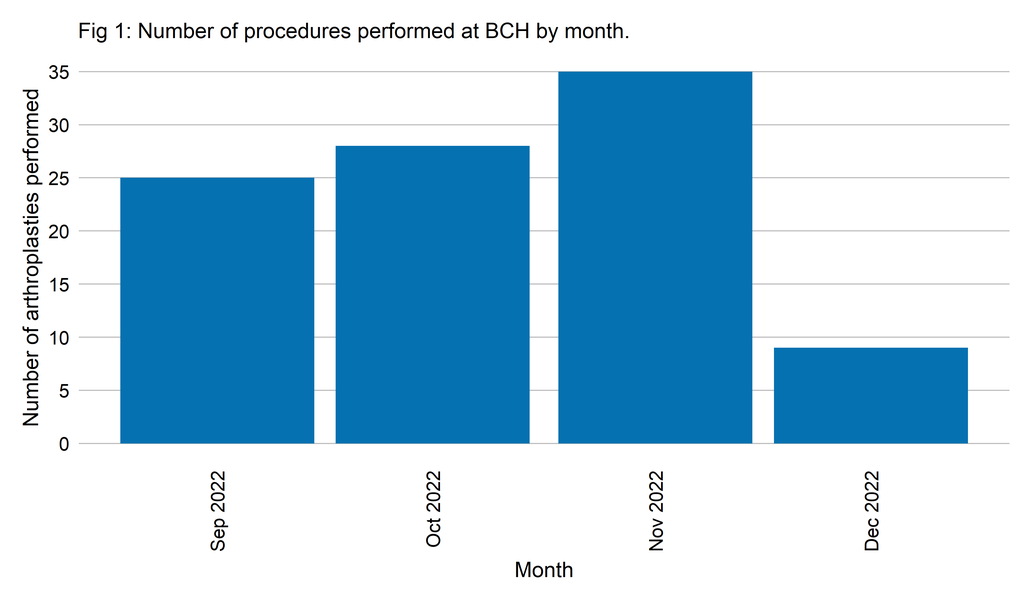

### Breakdown of procedures

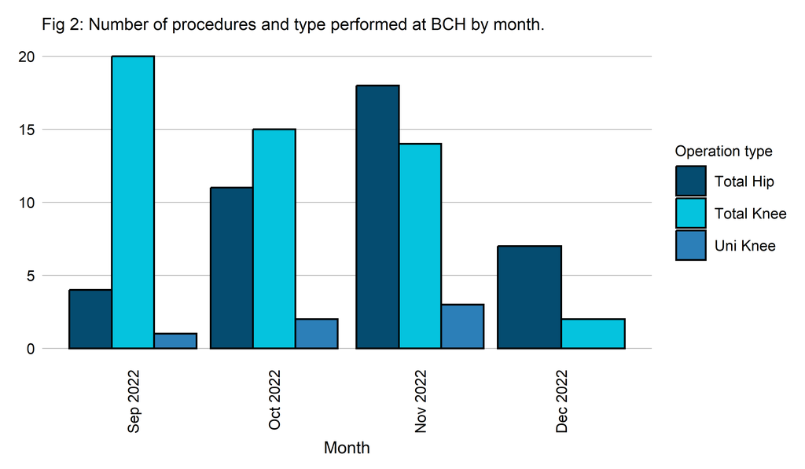

# Clinicians

## Surgeons

Between 02 September 2022 and 06 December 2022 13 different surgeons performed at least 1 arthoplasty at BCH. The median number of arthroplasties per month was 3 with an interquartile range of 2. Figure 3 demonstrates the number of procedures performed at BCH per month, each chart represents an individual surgeon.

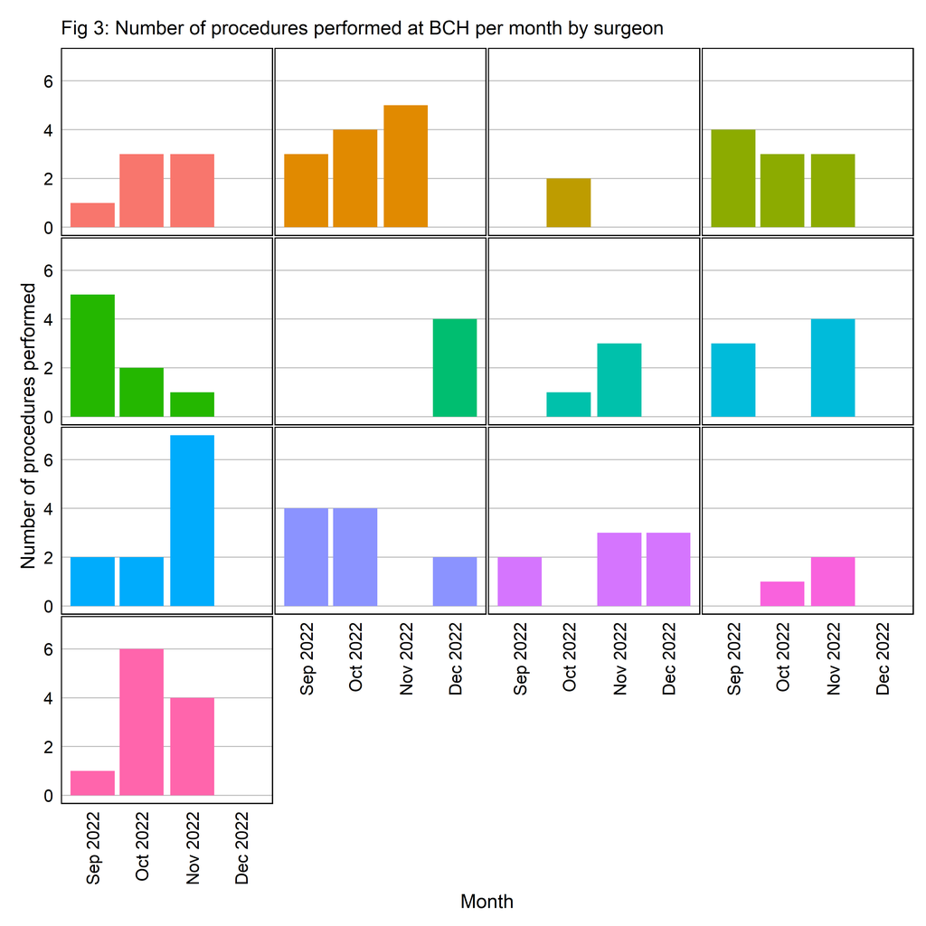

## Anaesthetists

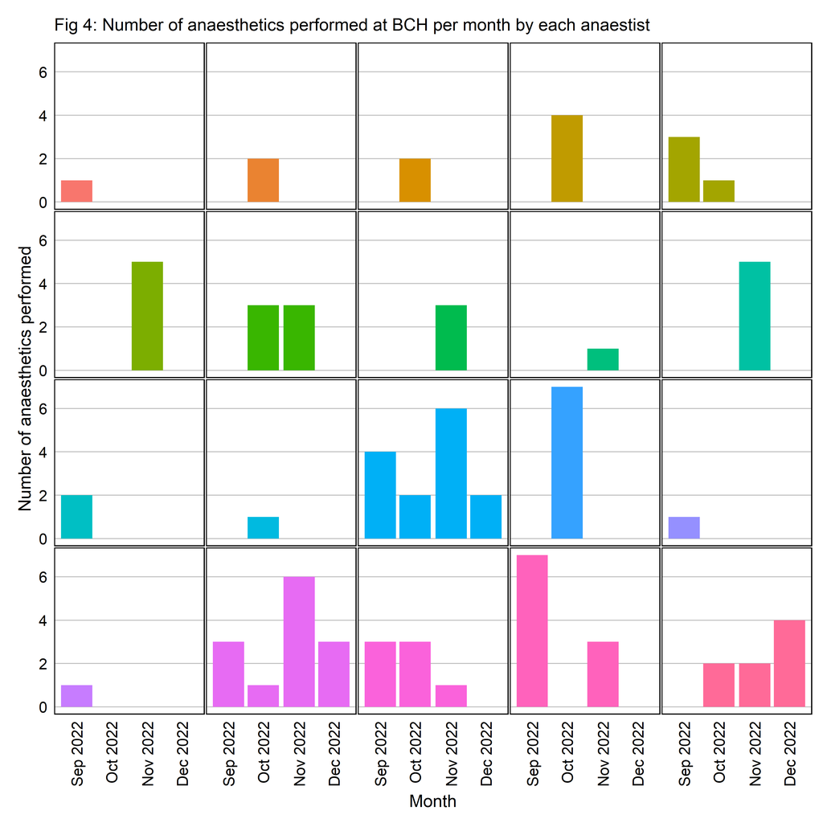

## Working together

Figure 5 below is a tree map. Each colour represents a different surgeon the size of the rectangle represents the number of arthroplasties performed by each one. The subdivision of each rectangle represents each anaesthetist they have worked with. The size of the sub division represents the number of arthroplasties performed by them together. Overall the tree map demonstrates the number of anaesthetists each surgeon has worked and the number of arthroplasties they have performed together as a team.

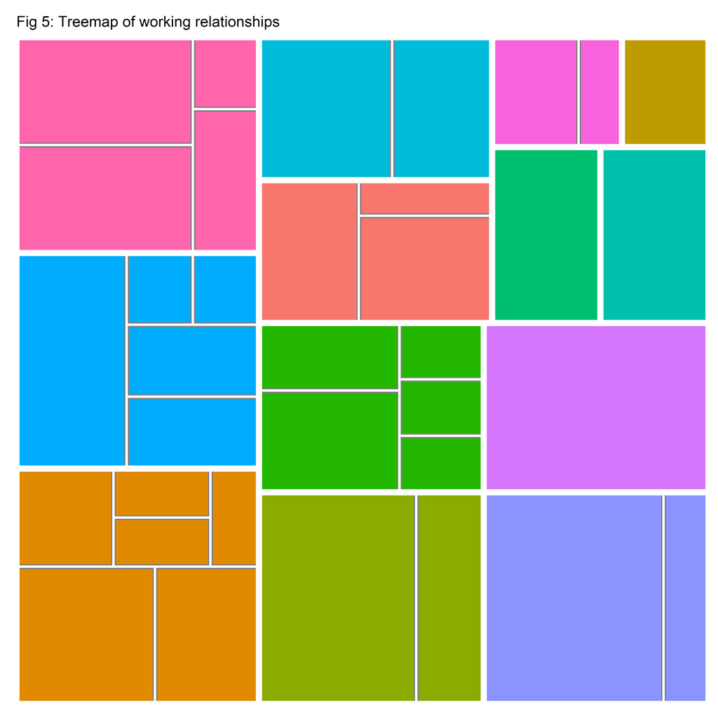

# Times

## Time into theatre

Figure 6 below is a histogram of the hour during which the patient arrived in theatre.

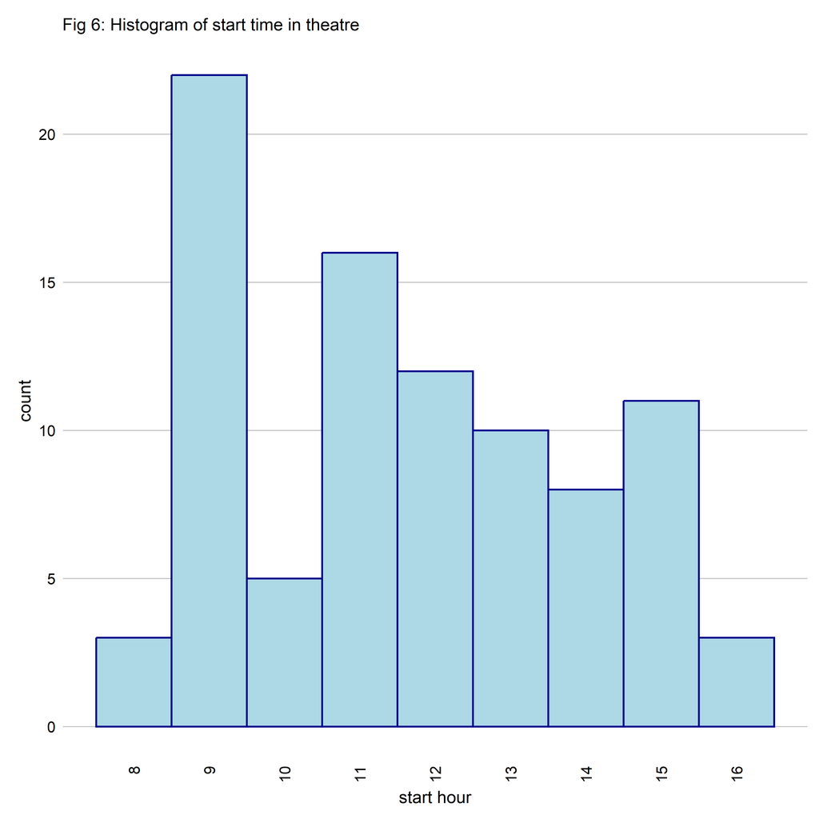

## Time back to ward

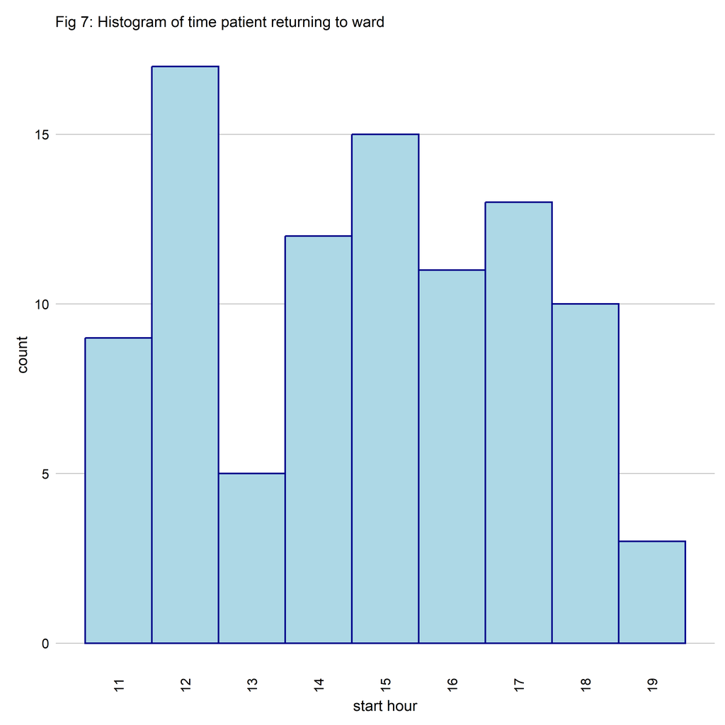

# Post Operative Course

## DrEaMing

A patient is said to be DrEaMing if they are drink, eating and mobilising within 24 hours of surgery. Firstly looking at the constituent parts:

### Drinking

On post operative day 1 there was drinking data available for 97 patients. Overall 92.8 % of patients were drinking on post operative day 1. Figure 8 below demonstrates the number of patients drinking and not drinking on post operative day 1, by month of surgery.

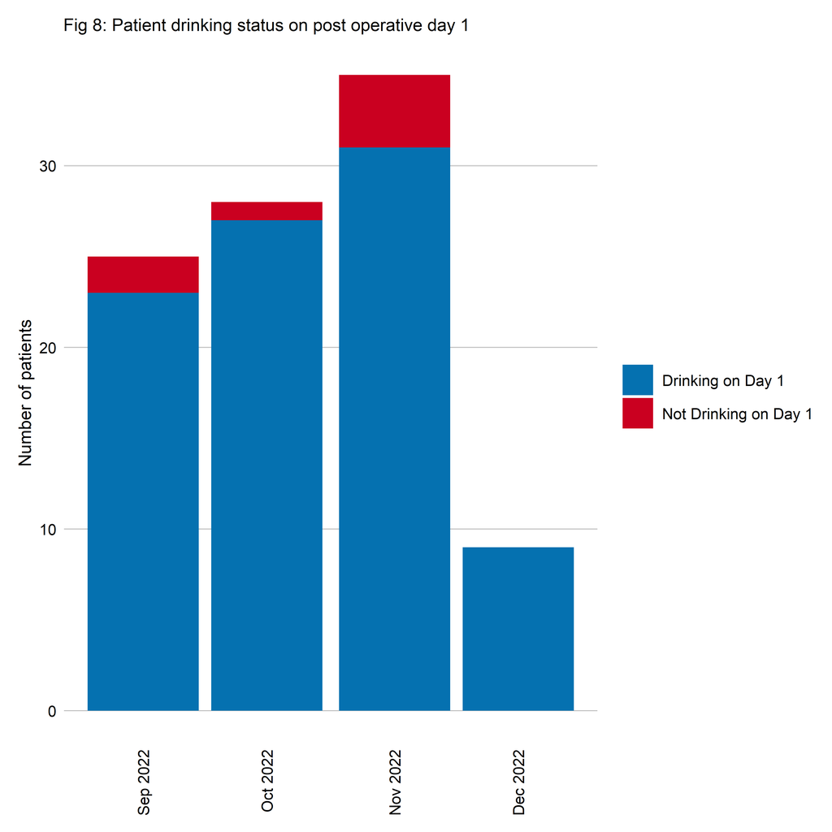

### Eating

On post operative day 1 there was eating data available for 97 patients. Overall 87.6 % of patients were eating on post operative day 1. Figure 9 below demonstrates the number of patients eating and those that were not on post operative day 1, by month of surgery.

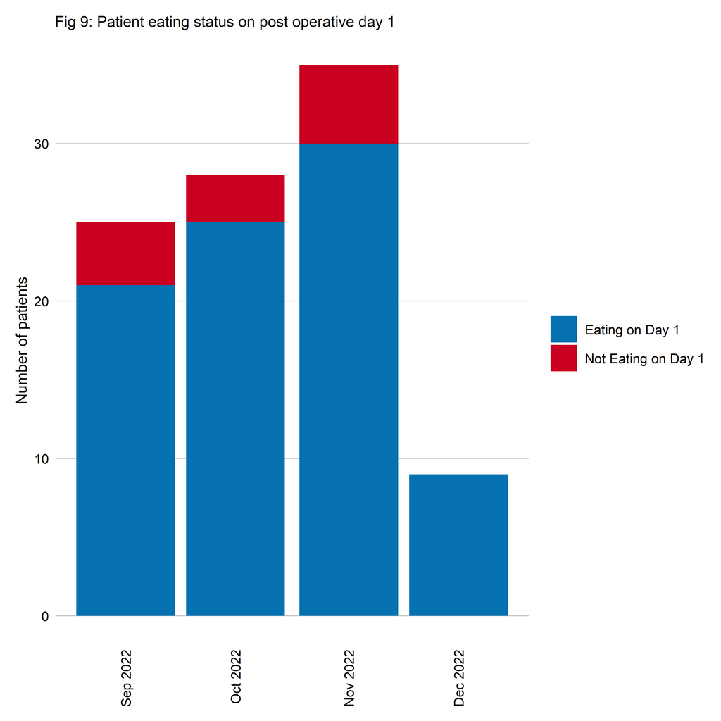

### Mobilising

On post operative day 1 there was data on mobilisation available for 97 patients. Overall 59.8 % of patients were mobilising on post operative day 1. Figure 10 below demonstrates the number of patients mobilising and those that were not on post operative day 1, by month of surgery.

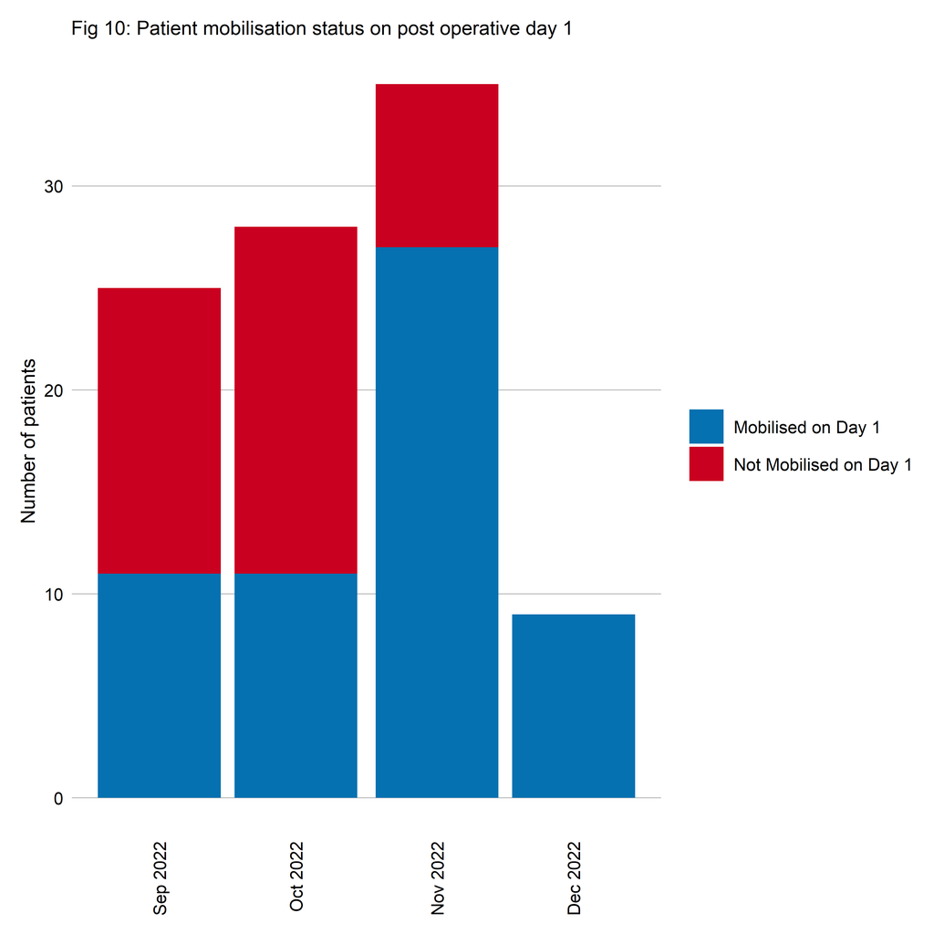

### DrEaMing

Drinking, eating and mobilising (DrEaMing) within 24 hours of surgery has been associated with reduced length of stay for certain surgical specialities. 58.8% of patients were DrEaMing at 24 hours. Figure 11 below demonstrates the number of patients DrEaMing and those that were not on post operative day 1, by month of surgery.

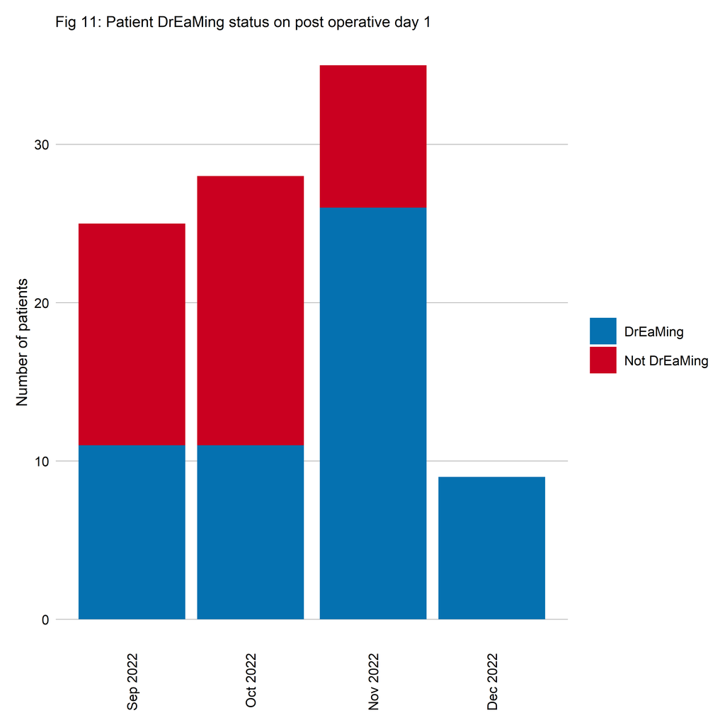

## To DO

Lollpop times Facet wrap histograms of times

Pain

Dreaming

# R Markdown

This report was produced using R Markdown. Markdown is a simple formatting syntax for authoring HTML, PDF, and Power point documents. For more details on using R Markdown see http://rmarkdown.rstudio.com.